# 06 - Exercícios de Visualização de Dados

## 3.3 **Modificando a aparência do gráfico**

- adicione transparência aos pontos

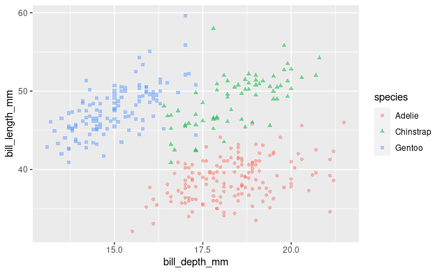

- alterando o título dos eixos x

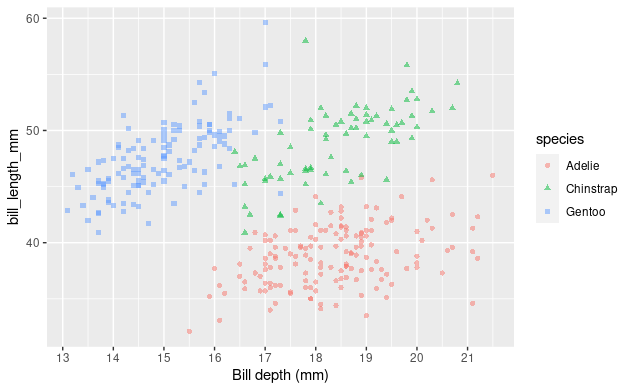

- alterando o título do eixo y

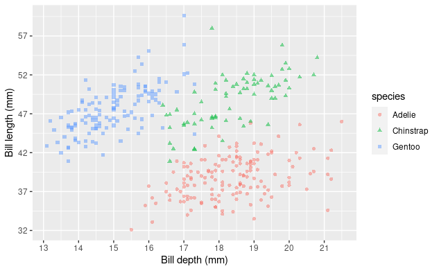

- alterando o título da legenda e as cores dos pontos

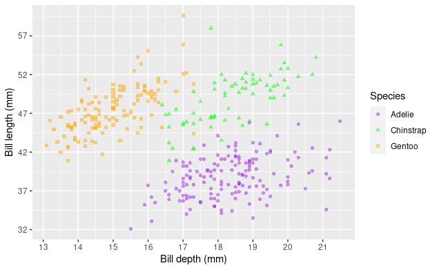

## 3.4 **Salvando o gráfico como um objeto**

## 3.5 **Adicionando o tema `meu_tema_barras`**

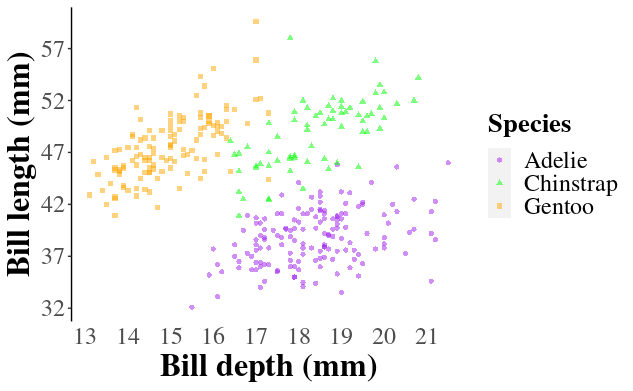

## 3.6 **Modificando um tema existente**

- adicionar linha no eixo x
- adicionar barras transversais no eixo x (ticks)
- ocultar fundo cinza nos rótulos da legenda
- salvar tema como novo objeto

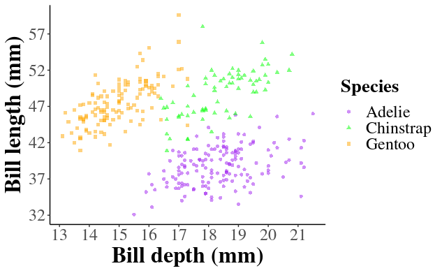

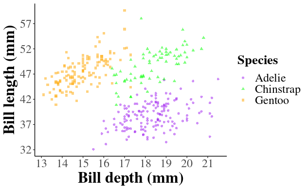

# 4 **Visualizando a variação do número de pinguins ao longo do tempo**

## 4.1 **Relação número de pinguins x anos**

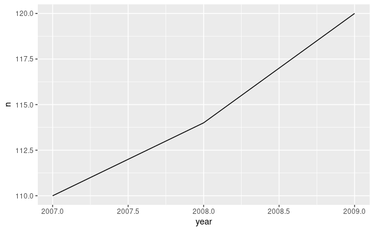

## 4.2 **Relação número de pinguins x anos por espécie**

- utilize o estético color para gerar uma linha para cada espécie com diferentes cores

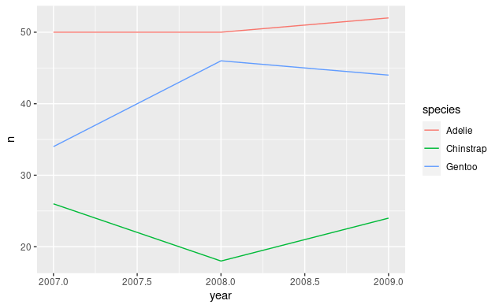

- utilize o estético linetype para gerar um tipo de linha para cada espécie

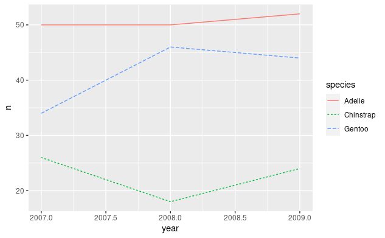

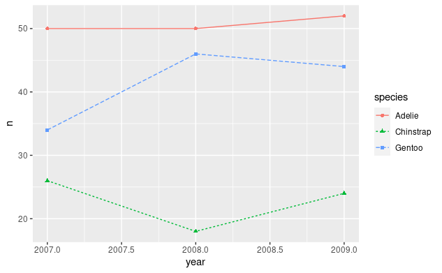

## 4.3 **Modificando a aparência do gráfico**

- alterando o título dos eixos x

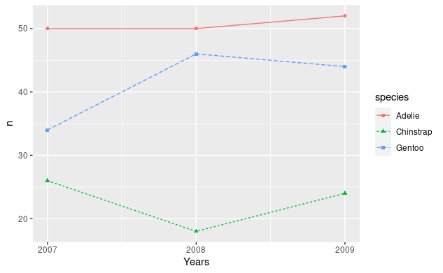

- alterando o título do eixo y

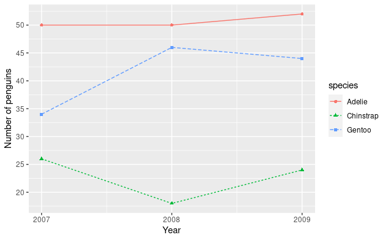

- alterando o título da legenda e as cores dos pontos

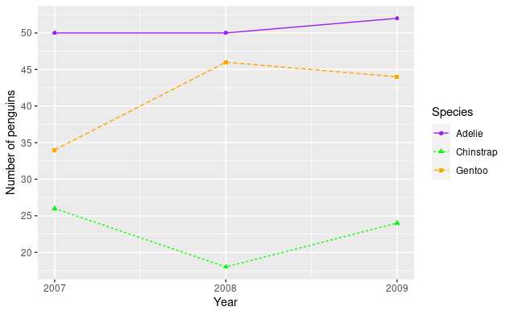

## 4.4 **Salvando o gráfico como um objeto e adicionar o tema `meu_tema_relacoes`**

- Adicionando o tema `meu_tema_relacoes`

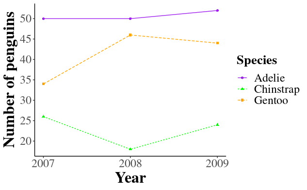